# Домашнее задание №3, Вариант 7

Кудряшов Александр

# Задание 1

## Условие

Пусть цена **Европейского Put** опциона с *X* = 100$ равна 1$, а текущая цена акции *S* = 103$. Найти цену **Американского Call** опциона с тем же страйком, если $r = 1%$ и $T = 3$. Ответ округлить до целых.

## Решение

Из **Put-Call Parity**, справедливого для европейских опционов, найдем цену **Европейского Сall**. Известно при этом, что цены **Американского Call** и **Европейского Сall** совпадают. Таким образом, цена **Американского Call**
$$C_A = C_E = P_E + \exp(-rT)(F - X) = P_E + \exp(-rT)(S\exp(rT) - X) =$$
$$= P_E + S - X\exp(-rT) = 1 + 103 - 100\exp(-0.03)\$ = 7 \$$$

# Задание 2

## Условие

Реализовать функции, вычисляющие:

- цену европейских опционов через формулу Блэка-Шоулза
- payoff’ы
- цену на i-ом шаге из цен i+1 шага
- цену европейских опционов при помощи биномиальной модели
- цену **Американского Put** при помощи биномиальной модели

Построить графики зависимости цен биномиальной модели от числа шагов *N*, используя следующие параметры: *S* = 130$, *X* = 130$,*T* = 1, *r* = 7%, $\sigma$ = 40%, *N* = 20:400.

Сравнить полученные результаты:

- Для европейских опционов с точным решением через Б-Ш
- Для **Американского Put** – с апроксимацией **Barone-Adesi & Whaley**

Поменять страйк на *X* = 108$, посмотреть на решение для **Европейского Call**, описать изменение поведения и причины этих изменений.

## Решение

Сперва реализуем функции для цен европейских опционов через формулу Блэка-Шоулза.

### Цены европейских опционов по формуле БШ

```r
# по формуле БШ вычисляем цену опциона при условии, что
# текущая цена базового актива S
# страйк-цена опциона X, ставка r, до экспирации dt, волатильность sigma
put_price <- function(S, X, r, dt, sigma){
  d1 <- (log(S / X) + (r + (sigma^2 / 2) * dt)) * 1 / sigma / dt^0.5
  d2 <- d1 - sigma * dt^0.5
  pnorm(-d2) * X * exp(-r * dt) - pnorm(-d1) * S
}

# через Call Put parity
call_price <- function(S, X, r, dt, sigma){
  put_price(S, X, r, dt, sigma) + S - X * exp(-dt *  r)
}
```

Теперь – для payoff’ов.

### Функции выплат для европейских опционов

```r
put_payoff <- function(S = 0:300, X, r, dt, sigma){
  # для простоты считаем, что цена базового актива
  # колеблется в диапазоне 0:300
  # вычисляем цены опциона для этого диапазона
  # так, тут, чтоб не запутаться, дополнительно поясню для себя
  # put_prices[i] - справедливая цена опциона пут при
  # 1) текущей цене базового актива S[i]
  # 2) страйк-цене опциона X, ставке процента r, времени до экспирации dt, волатильности sigma
  put_prices <- put_price(S, X, r, dt, sigma)
  # вычисляем выплаты
  # по идее для каждого возможного значения текущей put price
  # должен получиться вектор выплат для разных возможных значений
  # цены базового актива в момент экспирации
  # т.е. на выходе у нас должна быть матрица размерностью длина(put_prices) x длина(S) = длина(S) x длина(S)
  payoffs <- mapply(function(p_price, S_) {
                t <- X - S_  - p_price
                t[which(t < -p_price)] = - p_price
                t
                }
                , put_prices, t(replicate(length(put_prices), 0:X*3)))
  payoffs <- matrix(payoffs, nrow = length(S))
  payoffs
}

# и то же самое для call-опциона
call_payoff <- function(S = 0:X*3, X, r, dt, sigma){
  call_prices <- call_price(S, X, r, dt, sigma)
  payoffs <- mapply(function(c_price, S_) {
                t <- S_ - X  - c_price
                t[which(t < -c_price)] = -c_price
                t
                }
                , call_prices, t(replicate(length(call_prices), 0:300)))
  payoffs <- matrix(payoffs, nrow = length(S))
  payoffs
}
```

### Биномиальная модель для европейских опционов

**Идея биномиальной модели в следующем**. Пусть у нас есть *N* шагов по времени, каждый из которых либо повышает цену в *u* раз с вероятностью *p*, либо понижает её в *d* раз с вероятностью *1-p*. Значения параметров подбираются из предположения о том, что цена актива колеблется логнормально, и оценки матожидания и дисперсии для логнормального распределения цены и биномиальной модели должны совпадать[^1]. Поэтому для матожидания цены через *dt* имеем равенство:
$$puS + d(1-p)S = (1 +\mu dt)S$$
Здесь левая часть $puS + d(1-p)S$ - матожидание цены базового актива через 1 шаг в биномиальной модели, а правая часть – цена базового актива через 1 шаг (размером *dt*) в логнормальном распределении. Ведь если $\mu$ – матожидание логнормального распределения, это значит, что через время *dt* матожидание цены базового актива будет $Se^{\mu dt} \approx S(1 + \mu dt)$[^2]

Аналогичное равенство должно выполняться для дисперсии[^3]:
$$p(uS - (1 + \mu dt)S)^2 + (1 - p)(dS - (1 + \mu dt)S)^2 = \sigma S^2 dt$$

Если теперь предположить, что промежуток *T* не слишком велик, можно сказать, что тренда в колебаниях цены не наблюдатеся и $ud = 1$, $\mu = 0$. Из этих предположений:
$$u = e^{\sigma\sqrt{\Delta t}}$$
$$d = e^{-\sigma\sqrt{\Delta t}}$$
$$p = (e^{r\Delta t} - d)/(u - d)$$
Теперь просто взвешенно суммируем с соответствующими вероятностями возможные цены базового актива на момент времени *T*, каждой из таких цен соответствует своя цена опциона. В сумме получится оценка цены опциона на данный момент.

$$(call \space price) = e^{-rT}\sum_{i=0}^{n}{C_n^ip^i(1-p)^{n-i}\space max[Su^i d^{n- i} - X, 0]}$$

$$(put \space price) = e^{-rT}\sum_{i=0}^{n}{C_n^ip^i(1-p)^{n-i}\space max[X - Su^i d^{n- i}, 0]}$$

В значительном числе случаев $max[X-Su^id^{n-i}, 0] = 0$, т.к. это, по сути, формула выплаты по опциону в зависимости от цены базового актива и мы знаем её вид – сперва непрерывное убывание, потом 0. Удобно обозначить через $a = округление\_вверх{\frac{ln(\frac{X}{Sd^n})}{ln(u/d)}}$ и уменьшить время рассчета цен на компьютере:

$$(call \space price) = e^{-rT}\sum_{i=a}^{n}{C_n^ip^i(1-p)^{n-i}\space [Su^i d^{n- i} - X]}$$
$$(put \space price) = e^{-rT}\sum_{i=0}^{a-1}{C_n^ip^i(1-p)^{n-i}\space [X - Su^i d^{n- i}]}$$
Теперь просто запрограммруем их.

```r
# биномиальная модель для европейского сall
# S - цена базового актива, X - страйк-цена
# T - время до экспирации, r - ставка процента, sigma - волатильность
# N - число шагов
#  функции не векторизованы относительно S!
binomial_European_call <- function(S, X, r, T, sigma, N){
  # шаг по времени
  dt <- T/N
  u <- exp(sigma * sqrt(dt))
  d <- exp(-sigma * sqrt(dt))
  p <- (exp(r * dt) - d) / (u - d)
  a <-ceiling(log(X / (S * d^N)) / log(u/d))
  exp(-r*T) * sum(sapply(a:N, function(i) choose(N, i) * p^i * (1-p)^(N-i) * (S * u^i * d^(N-i) - X)))
}


binomial_European_put <- function(S, X, r, T, sigma, N){
  # шаг по времени
  dt <- T/N
  u <- exp(sigma * sqrt(dt))
  d <- exp(-sigma * sqrt(dt))
  p <- (exp(r * dt) - d) / (u - d)
  a <- ceiling(log(X / (S * d^N)) / log(u/d))
  -exp(-r*T) * sum(sapply(0:(a-1), function(i) choose(N, i) * p^i * (1-p)^(N-i) * (S * u^i * d^(N-i) - X)))
}
```

## Иллюстрация работы подхода

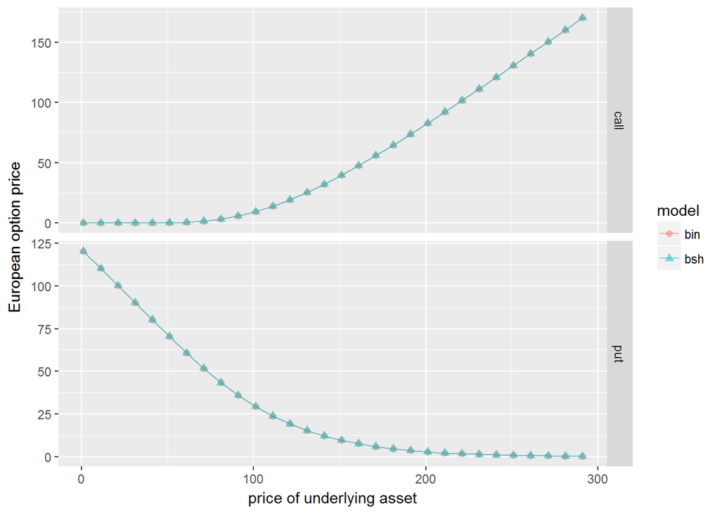

```r
  library(ggplot2)
  library(reshape2)
  S <- 130
  X <- 130
  T <- 1
  r <- 0.07
  sigma <- 0.4
  N <- 400
  df <- data.frame(price = seq(1, 300, 10))
  # используем sapply, т.к. ф. binomial_European_*  не векторизованы
  df$bin_put <- sapply(df$price, function(p) binomial_European_put(p, X, r, T, sigma, N))
  df$bin_call <- sapply(df$price, function(p) binomial_European_call(p, X, r, T, sigma, N))
  df$bsh_put <- put_price(df$price, X, r, T, sigma)
  df$bsh_call <- call_price(df$price, X, r, T, sigma)

  melted <- melt(df, id = 'price')
  melted$model <- sapply(strsplit(as.character(melted$variable),'_'), '[[', 1)
  melted$type <- sapply(strsplit(as.character(melted$variable),'_'), '[[', 2)

  ggplot(melted) +
    geom_point(aes(x = price, y = value, color = model, shape = model), size = 2, alpha = 0.5) +
    facet_grid(type ~ ., scale = 'free') +
    geom_line(aes(x = price, y = value, color = model), size = 0.5, alpha = 0.5) +
    xlab("price of underlying asset") +
    ylab("European option price")
```

Интересно, что совпадение почти идеальное. Однако это сравнение цен, подсчитанных на основе одной теоретической модели, и на основе другой теоретической. Как эти теоретические цены согласуются с реальными ценами реальных опционов? Все-таки при моделировании мы делали кучу неочевидных для меня теоретических допущений относительно законов рынка.[^4]

## Биномиальная модель для американских опционов

Поскольку известно, что **Aмериканский Call** торгуется по той же цене, что **Европейский Сall**, делаем все только для **Aмериканского Put**.

Алгоритм следующий:

1. Определяем *u*, *d*, *p*, $\Delta t$, стоим биномиальное дерево для цены базового актива.
2. Считаем теоретические цены базового актива c помощью биномиальной модели при всех $t = \Delta t * i, i=1:N$
3. Высчитываем справедливые цены опционов в момент $t = T$. Для **Американского Put** они находится просто: если цена базового актива *S* меньше цены страйк *X*, то прибыль от реализации опционного права будет $(X - S)e^{-rT}$[^5], иначе 0.
4. Проходимся в обратном порядке по “слоям” получившегося дерева, ищем из цен на j+1 шаге цены опционов на шаге j. Поскольку на j-ом шаге есть возможность реализовать опцион досрочно, формула для справедливых цен на опционы примет вид[^6]:

$$P_{j,i} = max[e^{-r\Delta t j}(X - Su^id^{j-i}),pP_{j+1, i+1} + (1-p)P_{j+1, i}]$$
По сути своей это просто математическая реализация следующей идеи: если на данном шаге опцион приносит больше прибыли, чем на следующих, его нужно реализовать, ведь у нас есть такое право. Прибыль на следующих шагах уже берется с учетом дисконтирования денег по времени, а прибыль на этом шаге дисконтируется. Здесь $P_{j, i}$ – цена опциона на шаге j по времени и на шаге i по цене базового актива. $e^{-r\Delta t j}$ – дисконтирование денег, $X$ – страйк цена опуиона, $Su^id^{j-i}$ – цена базового актива в точке сетки. $pP_{j+1, i+1} + (1-p)P_{j+1, i}$ – матожидание цены опциона на следующих шагах.При этом формула неявно подразумевает, что $P_{j+1, i+1}$ – справедливая цена опциона, в случае если от текущего положения цена базового актива пойдет вверх, а $P_{j+1, i}$ – цена опциона, если цена базового актива пойдет вниз, т.е. неявно предполагается, что у нас используется массив N x N в качестве базовой структуры для дерева, хотя, возможно, эффективнее было бы использовать другую реализацию дерева.

Теперь просто воплотим программно все вышесказанное.

```r
binomial_American_put <- function(S, X, r, T, sigma, N){
  # шаг по времени[^9]
  dt <- T/(N - 1)
  u <- exp(sigma * sqrt(dt))
  d <- exp(-sigma * sqrt(dt))
  p_ <- (exp(r * dt) - d) / (u - d)

  # инициализируем матрицу
  P <- matrix(rep(0, N*N), nrow = N)
  P[1, 1] <- S

  # из-за того, что у нас u*d = 1, можно сделать так
  for (i in 2:N)
    P[i, 1:i] <- c(P[i - 1, 1] * d, P[i - 1, 1:(i - 1)] * u)

  # справедливые цены в момент времени T
  P[N,] <- exp(-r * T) *  sapply(P[N, ], function(ss) max(X - ss, 0))
  # P[N,] <- sapply(P[N, ], function(ss) max(x - ss, 0))

  # теперь идем в обратном порядке
  for (j in (N - 1):1)
    for (i in 1:j)
      # P[j, i] <- max(exp(-j*dt) * (X - P[j, i]), p * (P[j + 1, i + 1]) + (1 - p) * P[j + 1, i])
      P[j, i] <- max(exp(-j*dt*r) * (X - P[j, i]), p_ * (P[j + 1, i + 1]) + (1 - p_) * P[j + 1, i])

  # возвращаем справедливую цену в данный момент времени
  P[1, 1]
}
```

## График зависимости цен биномиальной модели от числа шагов N для европейских опционов

Положим $S = 130\$$, $ X = 130$$, $T = 1$, $r = 7%$, $\sigma = 40%$, $N = 20:400$. Сперва посмотрим, что там с евпопейскими опционами.

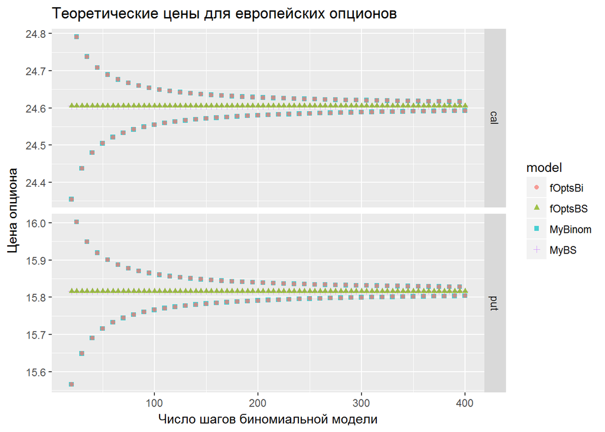

```r
library(fOptions)
eudf <- data.frame(N = seq(20,400,5))

# моя реализация формулы
eudf$putMyBS <- rep(put_price(S, X, r, T, sigma), length(eudf$N))
eudf$calMyBS <- rep(call_price(S, X, r, T, sigma), length(eudf$N))

# реализация fOptions формулы Блэка-Шоулза
eudf$putfOptsBS <- sapply(eudf$N, function(n) BlackScholesOption("p", S = S, X = X, Time = T, r = r, b = r, sigma = sigma)@price)
eudf$calfOptsBS <- sapply(eudf$N, function(n) BlackScholesOption("c", S = S, X = X, Time = T, r = r, b = r, sigma = sigma)@price)

# моя реализация биномиальной модели
eudf$putMyBinom <- sapply(eudf$N, function(n) binomial_European_put(S, X, r, T, sigma, n))
eudf$calMyBinom <- sapply(eudf$N, function(n) binomial_European_call(S, X, r, T, sigma, n))

# реализация биномиальной модели в fOptions
eudf$putfOptsBin <- sapply(eudf$N, function(n) CRRBinomialTreeOption("pe", S, X, T, r, r, sigma, n)@price)
eudf$calfOptsBin <- sapply(eudf$N, function(n) CRRBinomialTreeOption("ce", S, X, T, r, r, sigma, n)@price)


eudfmelted <- melt(eudf, id = 'N')
eudfmelted$type <- sapply(eudfmelted$variable, substring, 1, 3)
eudfmelted$model <- sapply(eudfmelted$variable, substring, 4, 10)
ggplot(eudfmelted) +
  geom_point(aes(x = N, y = value, colour = model, shape = model), alpha = 0.7) +
  facet_grid(type ~ ., scales = 'free') +
  xlab("Число шагов биномиальной модели") +
  ylab("Цена опциона") +
  ggtitle("Теоретические цены для европейских опционов")
```

## График зависимости цен биномиальной модели от числа шагов N для американского пут опциона

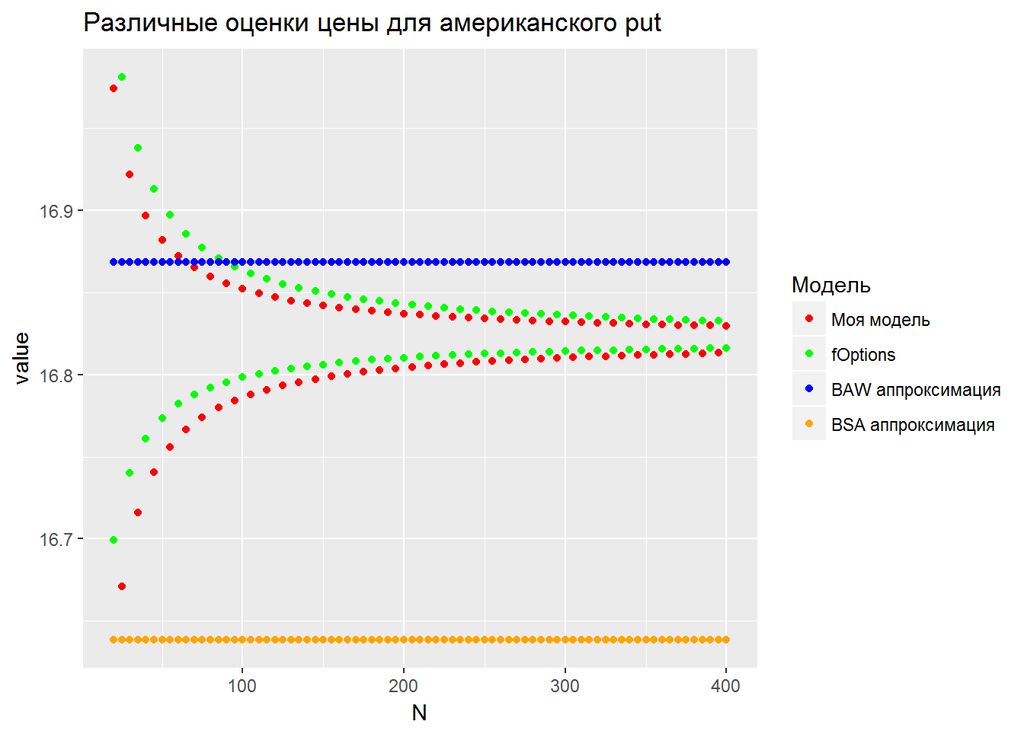

```r
amdf <- data.frame(N = seq(20,400,5))

# моя реализация биномиальной модели
amdf$putMyBinom <- sapply(eudf$N, function(n) binomial_American_put(S, X, r, T, sigma, n))

# реализация fOptions
amdf$putfOpt <- sapply(eudf$N, function(n) CRRBinomialTreeOption("pa", S, X, T, r, r, sigma, n)@price)

# Barone-Adesi
amdf$BAW <- rep(BAWAmericanApproxOption("p", S, X, T, r, r, sigma)@price, length(amdf$N))

# BSAmericanApproxOption
amdf$BSA <- rep(BSAmericanApproxOption("p", S, X, T, r, r, sigma)@price, length(amdf$N))

amdfmelted <- melt(amdf, id = "N")

ggplot(amdfmelted) +
  geom_point(aes(x = N, y = value, colour = variable)) +
  scale_color_manual(labels = c("Моя модель", "fOptions", "BAW аппроксимация", "BSA аппроксимация"), values = c("red", "green", "blue", "orange")) +
  labs(colour = "Модель") +
  ggtitle("Различные оценки цены для американского put")
```

Удивительно, что моя модель сходится чуть быстрее стандартной из пакета fOptions.

## Посмотрим, что будет с European Call, если теперь поменять страйк на X=108$

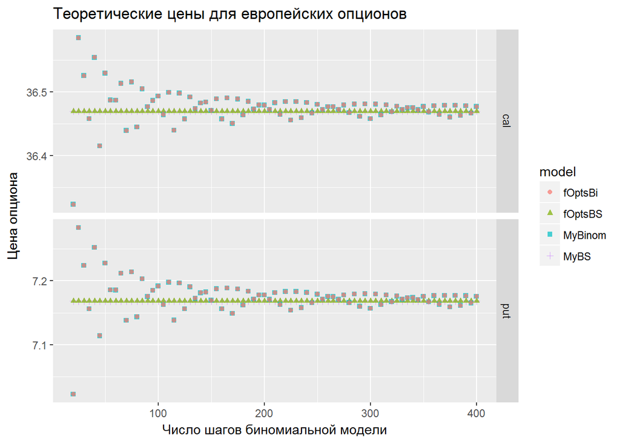

```r
X = 108
eudf <- data.frame(N = seq(20,400,5))

# моя реализация формулы
eudf$putMyBS <- rep(put_price(S, X, r, T, sigma), length(eudf$N))
eudf$calMyBS <- rep(call_price(S, X, r, T, sigma), length(eudf$N))

# реализация fOptions формулы Блэка-Шоулза
eudf$putfOptsBS <- sapply(eudf$N, function(n) BlackScholesOption("p", S = S, X = X, Time = T, r = r, b = r, sigma = sigma)@price)
eudf$calfOptsBS <- sapply(eudf$N, function(n) BlackScholesOption("c", S = S, X = X, Time = T, r = r, b = r, sigma = sigma)@price)

# моя реализация биномиальной модели
eudf$putMyBinom <- sapply(eudf$N, function(n) binomial_European_put(S, X, r, T, sigma, n))
eudf$calMyBinom <- sapply(eudf$N, function(n) binomial_European_call(S, X, r, T, sigma, n))

# реализация биномиальной модели в fOptions
eudf$putfOptsBin <- sapply(eudf$N, function(n) CRRBinomialTreeOption("pe", S, X, T, r, r, sigma, n)@price)
eudf$calfOptsBin <- sapply(eudf$N, function(n) CRRBinomialTreeOption("ce", S, X, T, r, r, sigma, n)@price)


eudfmelted <- melt(eudf, id = 'N')
eudfmelted$type <- sapply(eudfmelted$variable, substring, 1, 3)
eudfmelted$model <- sapply(eudfmelted$variable, substring, 4, 10)
ggplot(eudfmelted) +
  geom_point(aes(x = N, y = value, colour = model, shape = model), alpha = 0.7) +
  facet_grid(type ~ ., scales = 'free') +
  xlab("Число шагов биномиальной модели") +
  ylab("Цена опциона") +
  ggtitle("Теоретические цены для европейских опционов")
```

# Примечания и неясности

[^1]: Важный для меня момент тут в том, что я до этого не осознавал, что если в цене базового актива за период есть тренд, соответствующее базовому активу распределение все равно, скорее всего, будет логнормальным, просто с матодижанием $\ne 0$.
[^2]: По неочевидным для меня причинам берутся первые два члена из ряда Тейлора для экспоненты, а не сама экспонента.
[^3]: Левая часть – просто формула дисперсии для цены актива. А правая часть вызывает вопросы.Почему там не $\sigma^2$?
[^4]: Хочется это потом как-нибудь дополнительно поисследовать.
[^5]: В презентации с семинара, однако, справедливую цену не дисконтируют. Почему?
[^6]: И здесь цены не дисконтируют, если смотреть по конспекту. С другой стороны, согласно моим формулам получается, что цены дисконтируют несколько раз?
[^7]: На самом деле видно довольно плохо, т.к. одни значения накладываются на другие, но у меня нет в голове хорошей идеи того, как можно визуально доходчиво через график показать, что результаты практически идентичные.